# Communicate Data Funding ( USA YouTube dataset)

## Let's have a look at some features' ranking first

## The top 15 views of video

#### The best indicator for virality would be the counting on views.

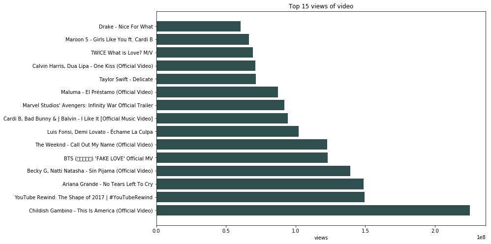

```python
top10(youtube, 'views', 15)
```

#### No wonder Childish Gambino is Grammy Winner, the official video had over 200 million views, till now, it has 479 million views, 7.6 million likes. Beside it, most of top 15 videos are music video, I could assume Music is one the most popular category.

## Top 15 likes of video

#### Along with views, we could conclude if the video is popular or not.

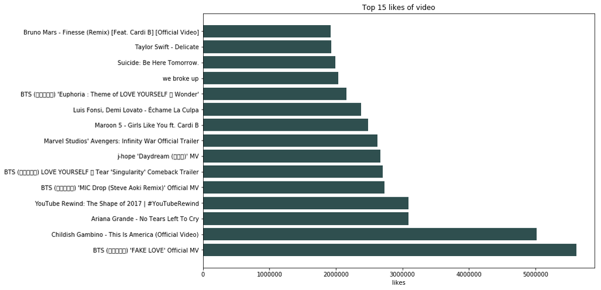

```python
top10(youtube, 'likes', 15)
```

## Top 15 dislikes of video

#### I believe only first two videos are truely hated by audiences. Others are due to the highly viewed by people, since dislikes and views are correlated.

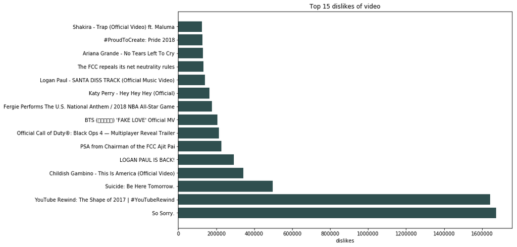

```python
top10(youtube, 'dislikes', 15)
```

## Top 15 comments of video

#### Comments could be positive, negative and neutral, so it can’t help to decide the popularity pretty much. However, I believe comments reflects views.

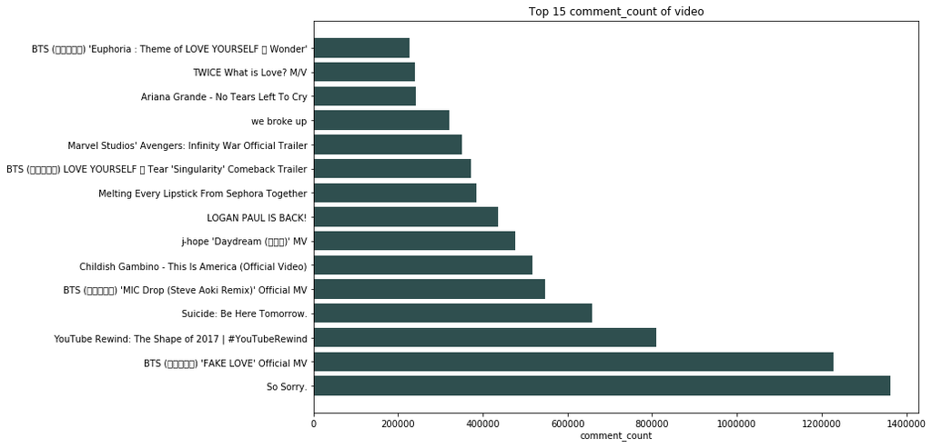

```python
top10(youtube, 'comment_count', 15)
```

#### As I said, comments are unable to reflect trueth about the popularity. The most commented one -- So Sorry, is the most disliked one, and the second -- BTS 'FAKE LOVE' Official MV is the most like one .

## Count on category

#### The bars show number of each category, orderder from most to least.

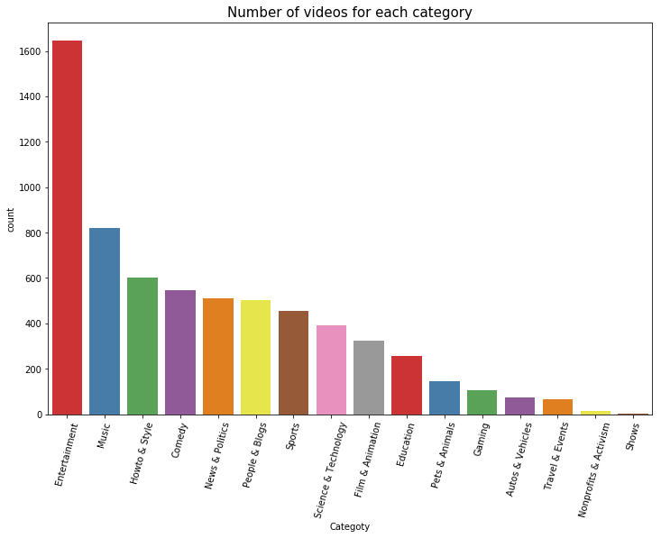

```python
fig,ax=plt.subplots(figsize=(12,8))
sns.countplot(data = youtube, x = 'category', palette = 'Set1', order = ['Entertainment', 'Music','Howto & Style','Comedy','News & Politics','People & Blogs','Sports','Science & Technology','Film & Animation','Education','Pets & Animals','Gaming','Autos & Vehicles','Travel & Events','Nonprofits & Activism', 'Shows'])
plt.xticks(rotation = 75)
plt.xlabel('Categoty')
plt.title('Number of videos for each category', fontsize = 15)
plt.show()
```

#### Top categories are Entertainment, Music, Howto & Style, Comedy, News & Politics, people & Blogs.

## WordCloud for top catefories

#### We pick most 100 frequent words, larger size for more frequent word, which give us a short and detailed description about each category.

## Entertainment

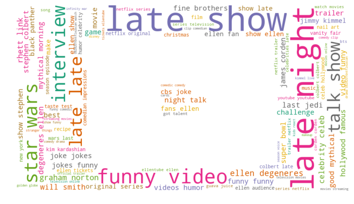

```python
tags = youtube[youtube['category'] == 'Entertainment']['tags'].str.lower().str.cat(sep = ' ')
wc(tags)
```

## Music

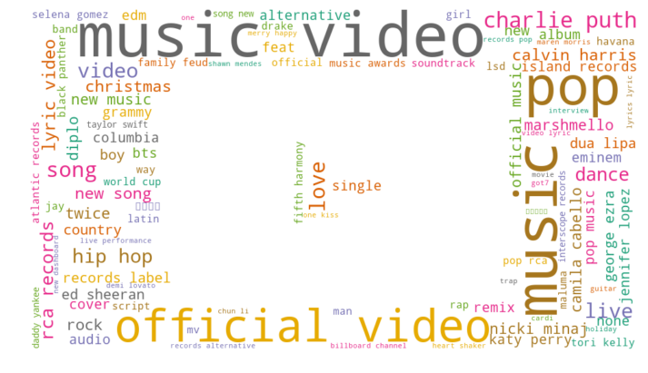

```python
tags = youtube[youtube['category'] == 'Music']['tags'].str.lower().str.cat(sep = ' ')
wc(tags)
```

## Howto & Style

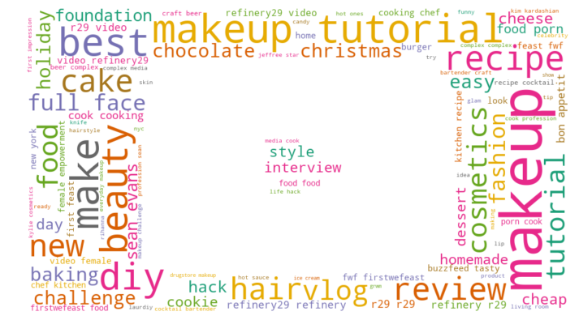

```python
tags = youtube[youtube['category'] == 'Howto & Style']['tags'].str.lower().str.cat(sep = ' ')
wc(tags)
```

## Comedy

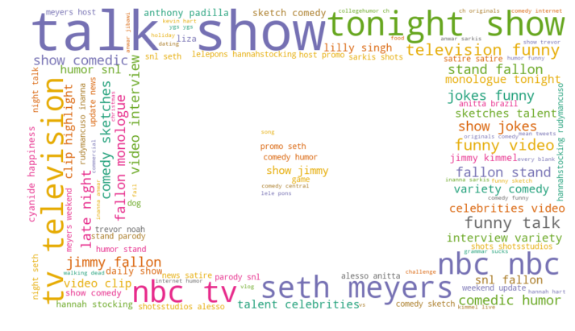

```python
tags = youtube[youtube['category'] == 'Comedy']['tags'].str.lower().str.cat(sep = ' ')
wc(tags)
```

## News & Politics

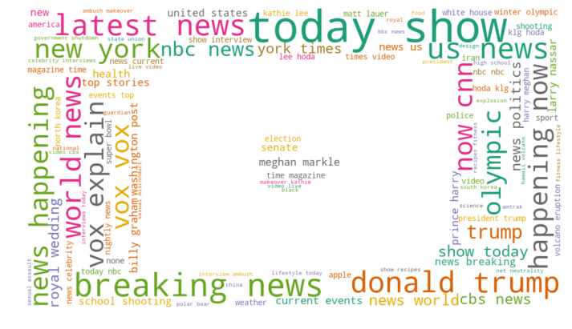

```python
tags = youtube[youtube['category'] == 'News & Politics']['tags'].str.lower().str.cat(sep = ' ')
wc(tags)
```

## People & Blogs

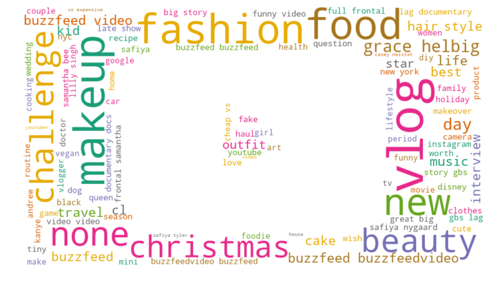

```python
tags = youtube[youtube['category'] == 'People & Blogs']['tags'].str.lower().str.cat(sep = ' ')
wc(tags)
```

## Most influenced publisher

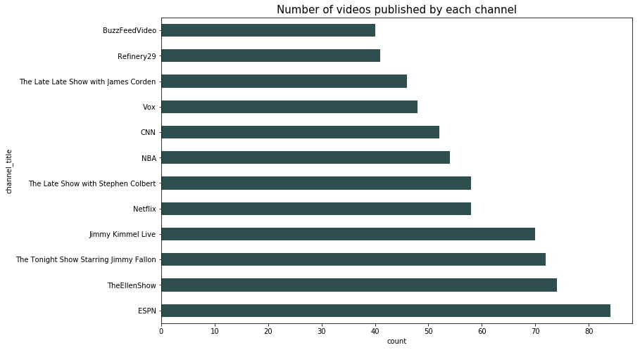

```python
top_publisher = publisher[publisher['video_id']>=40]
top_publisher.plot(kind = 'barh',legend=False, color='darkslategrey',figsize=(12,8))
plt.xlabel('count')
plt.title('Number of videos published by each channel', fontsize = 15)
plt.show()
```

## Rate distribution

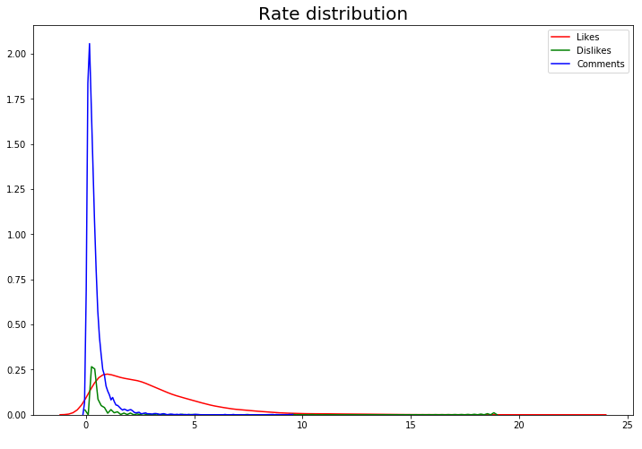

```python
youtube['like_rate']=youtube['likes']/youtube['views']*100
youtube['dislike_rate']=youtube['dislikes']/youtube['views']*100
youtube['comment_rate']=youtube['comment_count']/youtube['views']*100

plt.figure(figsize = (12,8))
plt.title('Rate distribution', fontsize = 20)
sns.distplot(youtube['like_rate'],color='red',hist=False,label='Likes')
sns.distplot(youtube['dislike_rate'],color='green',hist=False,label='Dislikes')
sns.distplot(youtube['comment_rate'],color='blue',hist=False,label='Comments')
plt.xlabel(' ')
plt.show()
```

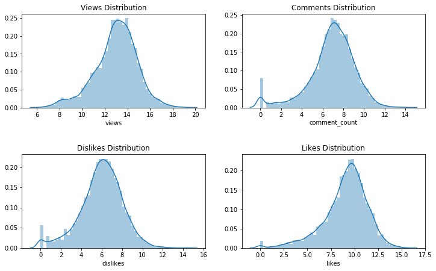

```python
plt.figure(figsize=(12,8))

plt.subplot(221)
sns.distplot(np.log(youtube['views']+1))
plt.title('Views Distribution',fontsize=12)

plt.subplot(222)
sns.distplot(np.log(youtube['comment_count']+1))
plt.title('Comments Distribution', fontsize=12)

plt.subplot(223)
sns.distplot(np.log(youtube['dislikes']+1))
plt.title('Dislikes Distribution', fontsize=12)

plt.subplot(224)
sns.distplot(np.log(youtube['likes']+1))
plt.title('Likes Distribution', fontsize=12)

plt.subplots_adjust(wspace = 0.2, hspace = 0.5,top = 0.8)
```

## BEST time to publish

#### We extract the time by day and month, apply bar graph to look at each day/month, how many videos published/trending.

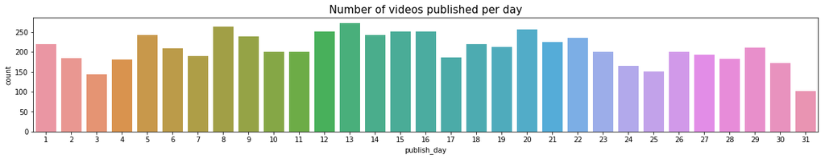

```python
plt.rcParams['figure.figsize']=(20,3)
sns.countplot(data = youtube, x = 'publish_day')
plt.title('Number of videos published per day', fontsize = 15)
plt.show()
```

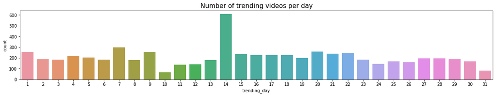

```python
sns.countplot(data = youtube, x = 'trending_day')
plt.title('Number of trending videos per day', fontsize = 15)
plt.show()
```

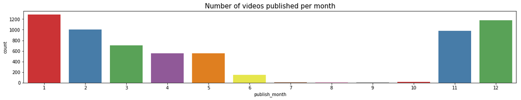

```python
sns.countplot(data = youtube, x = 'publish_month', palette='Set1')
plt.title('Number of videos published per month', fontsize = 15)
plt.show()
```

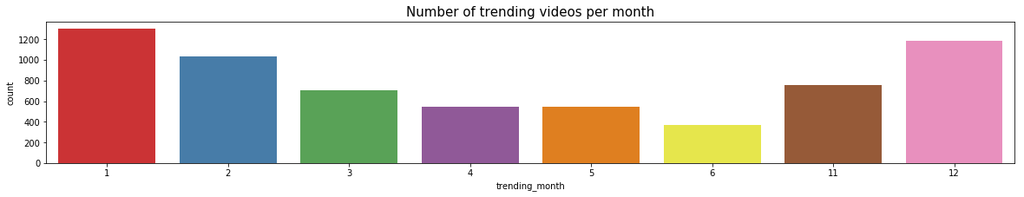

```python
sns.countplot(data = youtube, x = 'trending_month', palette='Set1')
plt.title('Number of trending videos per month', fontsize = 15)
plt.show()
```

## Heatmap of trending duration on different category

#### Besides the number of videos, the trending time of the video is also an important indicator to its popularity.

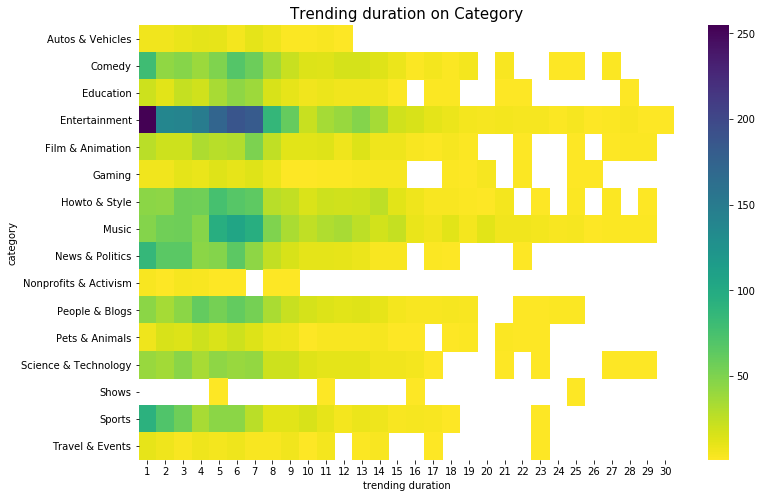

```python
youtube= pd.merge(youtube, duration, on = 'title')
fig,ax=plt.subplots(figsize=(12,8))
sns.heatmap(youtube.groupby(['category','trending_duration']).count()['video_id'].unstack(), cmap = 'viridis_r')
plt.title('Trending duration on Category', fontsize = 15)
plt.xlabel('trending duration')
plt.show()
```

## Audiences’ reflection delivered by views, likes, dislikes, comments. Here I apply boxplot, which is meaningful when one is categorical variable, the other is numeric variable.

## Displaying views(log) distribution by category

#### The views doesn’t related to the category that much.

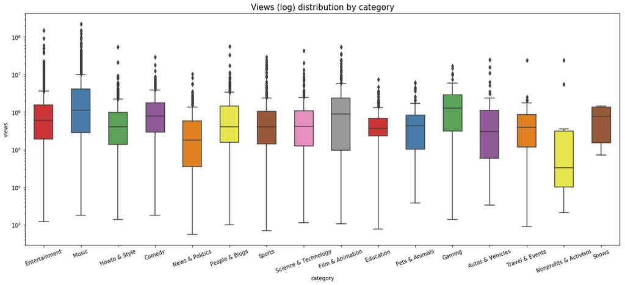

```python
plt.figure(figsize = (20,8))
plt.title('Views (log) distribution by category', fontsize = 15)
plt.yscale('log')
plt.xticks(rotation=20)
sns.boxplot(x='category',y='views',data=youtube, width=0.5,palette='Set1', order = ['Entertainment', 'Music','Howto & Style','Comedy','News & Politics','People & Blogs','Sports','Science & Technology','Film & Animation','Education','Pets & Animals','Gaming','Autos & Vehicles','Travel & Events','Nonprofits & Activism', 'Shows'])
plt.show()
```

## Displaying likes(log) distribution by category

#### As we expected, likes don't get influenced by categogry

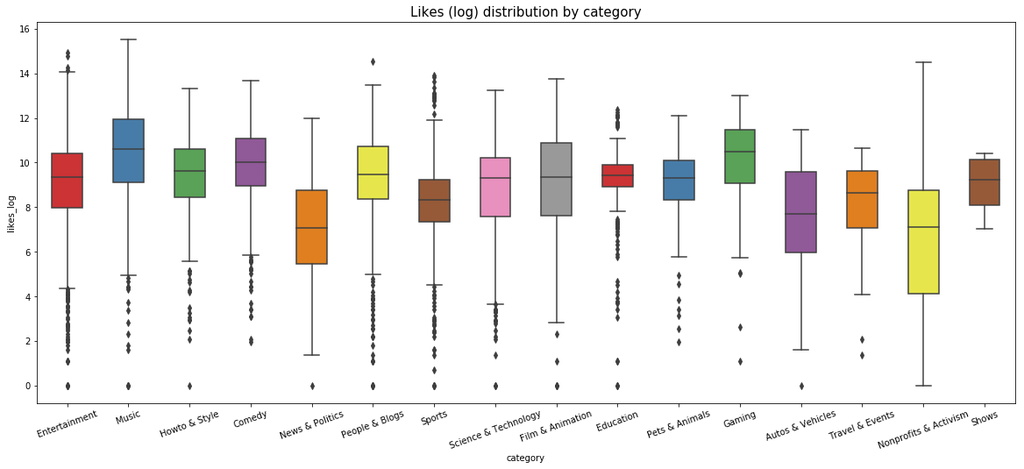

```python
youtube['likes_log'] = np.log(youtube['likes']+1)

plt.figure(figsize = (20,8))
plt.title('Likes (log) distribution by category', fontsize = 15)
plt.xticks(rotation=20)
sns.boxplot(x='category',y='likes_log',data=youtube, width=0.5,palette='Set1', order = ['Entertainment', 'Music','Howto & Style','Comedy','News & Politics','People & Blogs','Sports','Science & Technology','Film & Animation','Education','Pets & Animals','Gaming','Autos & Vehicles','Travel & Events','Nonprofits & Activism', 'Shows'])
plt.show()
```

## Displaying dislikes(log) distribution by category

#### Dislikes don't get influenced by category either.

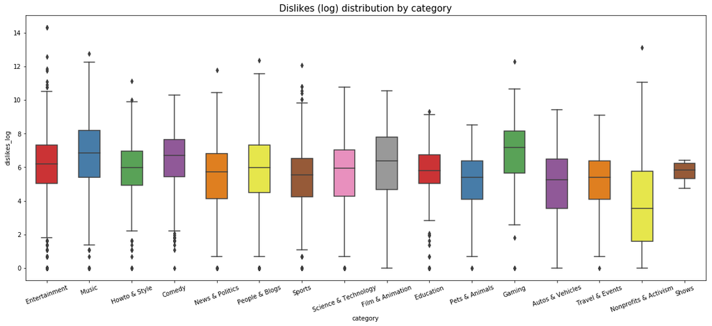

```python
youtube['dislikes_log'] = np.log(youtube['dislikes'] + 1)

plt.figure(figsize = (20,8))
plt.title('Dislikes (log) distribution by category', fontsize = 15)
plt.xticks(rotation=20)
sns.boxplot(x='category',y='dislikes_log',data=youtube, width=0.5,palette='Set1', order = ['Entertainment', 'Music','Howto & Style','Comedy','News & Politics','People & Blogs','Sports','Science & Technology','Film & Animation','Education','Pets & Animals','Gaming','Autos & Vehicles','Travel & Events','Nonprofits & Activism', 'Shows'])
plt.show()
```

## Displaying comments(log) distribution by category

#### Comments don't get influenced by category either.

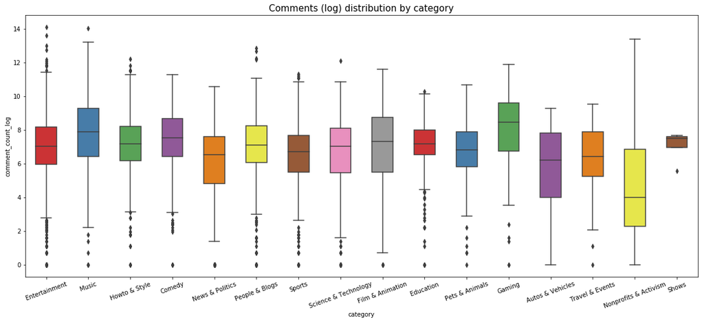

```python
youtube['comment_count_log'] = np.log(youtube['comment_count'] + 1)

plt.figure(figsize = (20,8))
plt.title('Comments (log) distribution by category', fontsize = 15)
plt.xticks(rotation=20)
sns.boxplot(x='category',y='comment_count_log',data=youtube, width=0.5,palette='Set1', order = ['Entertainment', 'Music','Howto & Style','Comedy','News & Politics','People & Blogs','Sports','Science & Technology','Film & Animation','Education','Pets & Animals','Gaming','Autos & Vehicles','Travel & Events','Nonprofits & Activism', 'Shows'])
plt.show()
```

## The impact of views on liks vs. dislikes

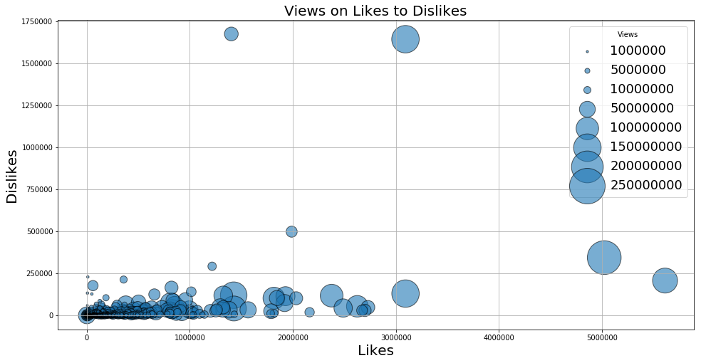

```python
plt.figure(figsize = (16,8))
plt.grid()
plt.scatter(data = youtube, x = 'likes', y = 'dislikes', s = youtube['views']/100000, edgecolors='black', alpha = 0.6)
plt.title('Views on Likes to Dislikes', fontsize = 20)
plt.xlabel('Likes', fontsize = 20)
plt.ylabel('Dislikes', fontsize = 20)

size = [1000000, 5000000, 10000000, 50000000, 100000000, 150000000, 200000000, 250000000]
col = sns.color_palette()[0]
leg_obj = []
for s in size:
    leg_obj.append(plt.scatter([],[], s=s/100000, color = col, alpha = 0.6, edgecolors='black'))
plt.legend(leg_obj, size, title = 'Views',prop= {'size': 18})
plt.show()
```

#### As was expected, the views impact does exist. for majority videos, views sizes are medium, more likes do lead more dislikes, but in a small amount compares to likes.

## Relationship between each variables (views, likes, dislikes, comments)

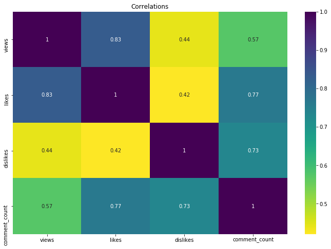

```python
plt.figure(figsize=(12,8))
sns.heatmap(youtube[['views', 'likes', 'dislikes', 'comment_count']].corr(), annot=True, cmap = 'viridis_r')
plt.title('Correlations')
plt.show()
```

#### 1) likes and views are highly correlated

#### 2) likes and comments are highly correlated

#### 3) comments and views are moderately correlated

#### 4) dislikes and views are low correlated

#### 5) dislikes and likes are low correlated